# Project 4

Author

Hector Gavilanes

```r
library(tidyverse)
library(gmodels) #prop.test
library(caret) # confusion matrix function
library(e1071) # confusion matrix function
library(cvms) # plot confusion matrix
library(ggimage) # arrows for confusion matrix plot
library(rsvg) # arrows for confusion matrix plot
library(gridExtra) #grid.arrange
library(formattable)
```

**Consider the [Palmer penguin data](https://allisonhorst.github.io/palmerpenguins/), available through the [`palmerpenguins` package](https://www.rdocumentation.org/packages/palmerpenguins/versions/0.1.1) in R. Note that if you are using R/RStudio on your own computer, you may need to install this package.**

```r
# clear environment
rm(list = ls())
# load data frame
data <- palmerpenguins::penguins

# custom colors
bar_colors <- c("#236AB9","#AE0D7A", "#448D76", "#B85B14")
```

**For all questions, assume $\alpha=0.05$.**

**1. Consider the sex (*sex*) of the penguins.**

```r
formattable(data) %>% count(sex)
```

| sex | n |
| --- | --- |
| female | 165 |
| male | 168 |
| NA | 11 |

**1a. It is known that the split of biological sex in humans is 50/50. Perform the appropriate hypothesis test to determine if the Palmer penguins have the same split.**

```r
# two proportion test
prop.test(x = c(165, 168),
          n = c(165+168, 165+168),
          correct = FALSE)
```

```
    2-sample test for equality of proportions without continuity correction

data:  c(165, 168) out of c(165 + 168, 165 + 168)
X-squared = 0.054054, df = 1, p-value = 0.8162
alternative hypothesis: two.sided
95 percent confidence interval:
 -0.08495299  0.06693497
sample estimates:
   prop 1    prop 2
0.4954955 0.5045045
```

**Hypotheses**

- $H_0: \ \pi_{\text{female}} = \pi_{\text{male}}$
- $H_1: \ \pi_{\text{female}} \ne \pi_{\text{male}}$

**Test Statistic and *p*-Value**

- $\chi^2_0 = 0.054$ or $z_0 = \sqrt{0.054} = 0.232$
- $p = 0.816$

**Rejection Region**

- Reject $H_0$ if $p < \alpha$; $\alpha=0.05$

**Conclusion/Interpretation**

- Keep $H_0$ at the $\alpha=0.05$ level. There is not sufficient evidence to suggest that the data does not follow a 50/50 split of biological sex in penguins.
- In other words, the data follows a 50/50 split of biological sex in penguins.

**1b. Find the 95% CI for the proportion of female penguins.**

```r
# two proportion test
prop.test(x = 165,
          n = 165+168,
          correct = FALSE)
```

```
    1-sample proportions test without continuity correction

data:  165 out of 165 + 168, null probability 0.5
X-squared = 0.027027, df = 1, p-value = 0.8694
alternative hypothesis: true p is not equal to 0.5
95 percent confidence interval:
 0.4421534 0.5489403
sample estimates:
        p
0.4954955
```

- The 95% CI for the proportion of female penguins is (0.442, 0.549)

**2. Consider the species (*species*) of the penguins.**

```r
formattable(data) %>% count(species)
```

| species | n |
| --- | --- |
| Adelie | 152 |
| Chinstrap | 68 |
| Gentoo | 124 |

**2a. Use the appropriate hypothesis test to determine if there is an even split of species in the dataset.**

```r
# k > 2: goodness of fit (multiple proportions)
counts <- c(152,68,124)
probs <- c(1/3, 1/3, 1/3)
chisq.test(counts, p = probs)
```

```
    Chi-squared test for given probabilities

data:  counts
X-squared = 31.907, df = 2, p-value = 1.179e-07
```

**Hypotheses**

- $H_0$: The data follows an even split of penguin species.
- $H_1$: The data does not follow an even split of penguin species.

**Test Statistic and *p*-Value**

- $\chi_0^2=31.907$; $\ p < 0.001$

**Rejection Region**

- Reject $H_0$ if $p < \alpha$; $\alpha=0.05$

**Conclusion/Interpretation**

- Reject $H_0$ at the $\alpha=0.05$ level. There is sufficient evidence to suggest that the data does not follow an even split of penguin species.

**2b. Construct a graph to accompany the test performed in 2a.**

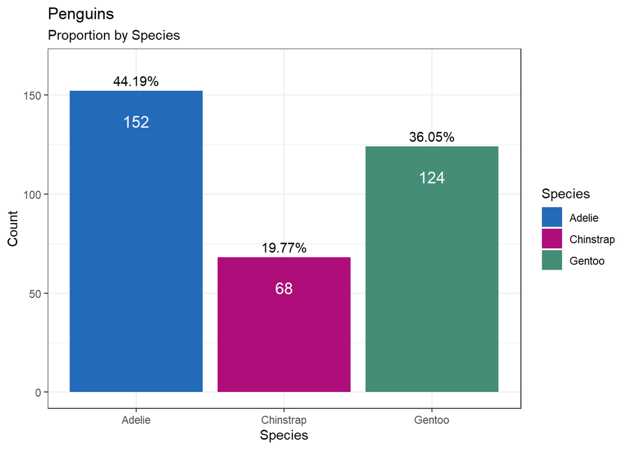

```r
species_count <- data %>%
  count(species) %>%
  mutate(freq = round((n/nrow(data)*100), 2)) %>%
  arrange(desc(n))

cp <- ggplot(species_count, aes(x = species, y = n, fill = species))+
  geom_col()+
  theme_bw()+
  scale_fill_manual(values= bar_colors)+
  labs(title = "Penguins",
       subtitle = "Proportion by Species",
       x = "Species",
       y = "Count",
       fill = 'Species')+
  geom_text(aes(x = species, y = n,
                label = paste0(round(freq, 2),"%")),
                vjust = -.5)+
  geom_text(aes(x = species, y = n,
                label = (n)),
                vjust = 3, cex = 4.5, colour = "white")+
  ylim(0,165)

cp
```

**3. Consider sex and species.**

**3a. Use the appropriate hypothesis test to determine if sex depends on species.**

```r
# contingency Table
CrossTable(data$sex, data$species,
           prop.r = FALSE, prop.t = FALSE, prop.chisq = FALSE, chisq = TRUE)
```

```
   Cell Contents
|-------------------------|
|                       N |
|           N / Col Total |
|-------------------------|


Total Observations in Table:  333


             | data$species
    data$sex |    Adelie | Chinstrap |    Gentoo | Row Total |
-------------|-----------|-----------|-----------|-----------|
      female |        73 |        34 |        58 |       165 |
             |     0.500 |     0.500 |     0.487 |           |
-------------|-----------|-----------|-----------|-----------|
        male |        73 |        34 |        61 |       168 |
             |     0.500 |     0.500 |     0.513 |           |
-------------|-----------|-----------|-----------|-----------|
Column Total |       146 |        68 |       119 |       333 |
             |     0.438 |     0.204 |     0.357 |           |
-------------|-----------|-----------|-----------|-----------|


Statistics for All Table Factors


Pearson's Chi-squared test
------------------------------------------------------------
Chi^2 =  0.04860717     d.f. =  2     p =  0.9759894
```

**Hypotheses**

- $H_0$: Sex does not depend on Species status.
- $H_1$: Sex depends on Species status.

**Test Statistic and *p*-Value**

- $\chi_0^2=0.049$; $\ p = 0.976$

**Rejection Region**

- Reject $H_0$ if $p < \alpha$; $\alpha=0.05$

**Conclusion/Interpretation**

- Keep $H_0$ at the $\alpha=0.05$ level. There is not sufficient evidence to suggest that Sex depends on Species status.

**3b. Construct a graph to accompany the test performed in 3a.**

```r
g_data <- data %>%
  select(species, sex) %>%
  group_by(species, sex) %>%
  drop_na() %>%
  count(sex)
# print table
formattable(g_data)
```

| species | sex | n |
| --- | --- | --- |
| Adelie | female | 73 |
| Adelie | male | 73 |
| Chinstrap | female | 34 |
| Chinstrap | male | 34 |
| Gentoo | female | 58 |
| Gentoo | male | 61 |

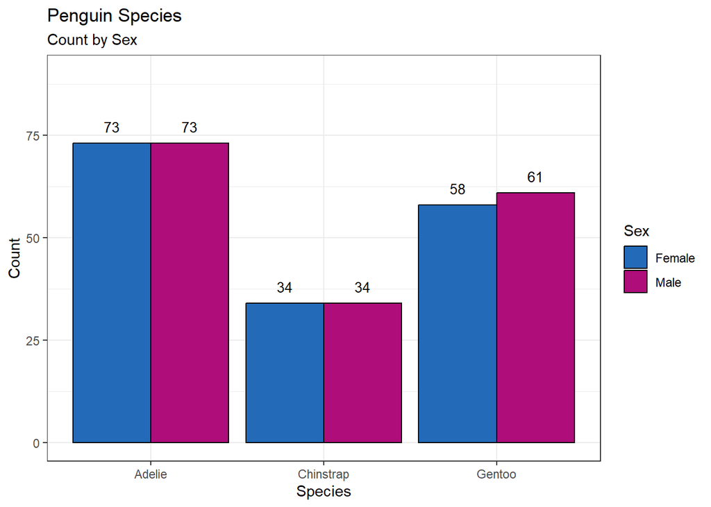

```r
g2 <- ggplot(g_data, aes(x = species, y = n, fill = sex))+
  geom_col(position = "dodge", colour = "black")+
  labs(title = "Penguin Species",
       subtitle = "Count by Sex",
       x = "Species",
       y = "Count",
       fill = 'Sex')+
  scale_fill_manual(values= bar_colors, labels = c("Female", "Male"))+
  theme_bw()+
  geom_text(mapping = aes(label = n), position = position_dodge(width = 0.9),
            cex = 3.5, vjust = -1)+
  ylim(0,90)

g2
```

```r
# get percentages
pct <- prop.table(table(data$species, data$sex), margin = 1)
#convert table to dataframe
pct <- as.data.frame(pct)
# rename columns
colnames(pct) <- c("species", "sex", "freq")
# print table
formattable(pct)
```

| species | sex | freq |
| --- | --- | --- |
| Adelie | female | 0.500000 |
| Chinstrap | female | 0.500000 |
| Gentoo | female | 0.487395 |
| Adelie | male | 0.500000 |
| Chinstrap | male | 0.500000 |
| Gentoo | male | 0.512605 |

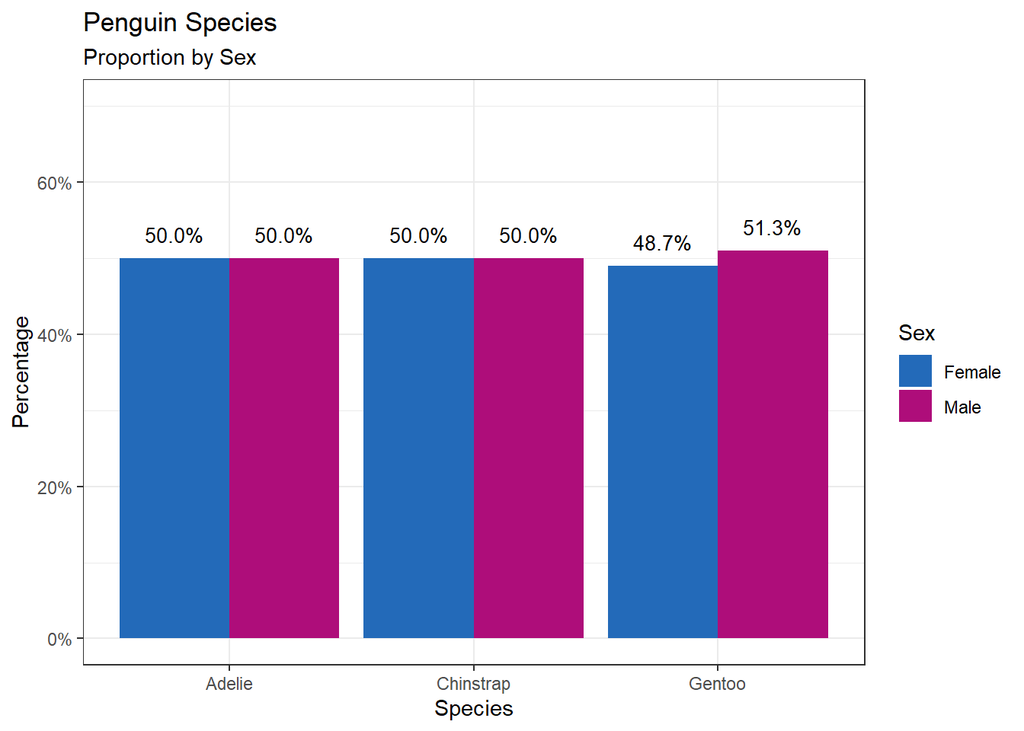

```r
# percentage plot
p2 <- ggplot(pct, aes(x = species, y = round(freq, 2), fill = sex))+
  # geom_bar(position = "fill")+
  geom_col(position = "dodge")+
  labs(title = "Penguin Species",
       subtitle = "Proportion by Sex",
       x = "Species",
       y = "Percentage",
       fill = 'Sex')+
  scale_fill_manual(values= bar_colors, labels = c("Female", "Male"))+
  theme_bw()+
  scale_y_continuous(labels = scales::percent, limits = c(0, .70))+
  geom_text(mapping = aes(label = scales::percent(freq)), position = position_dodge(width = 0.9),
            cex = 3.5, vjust = -1)

p2
```

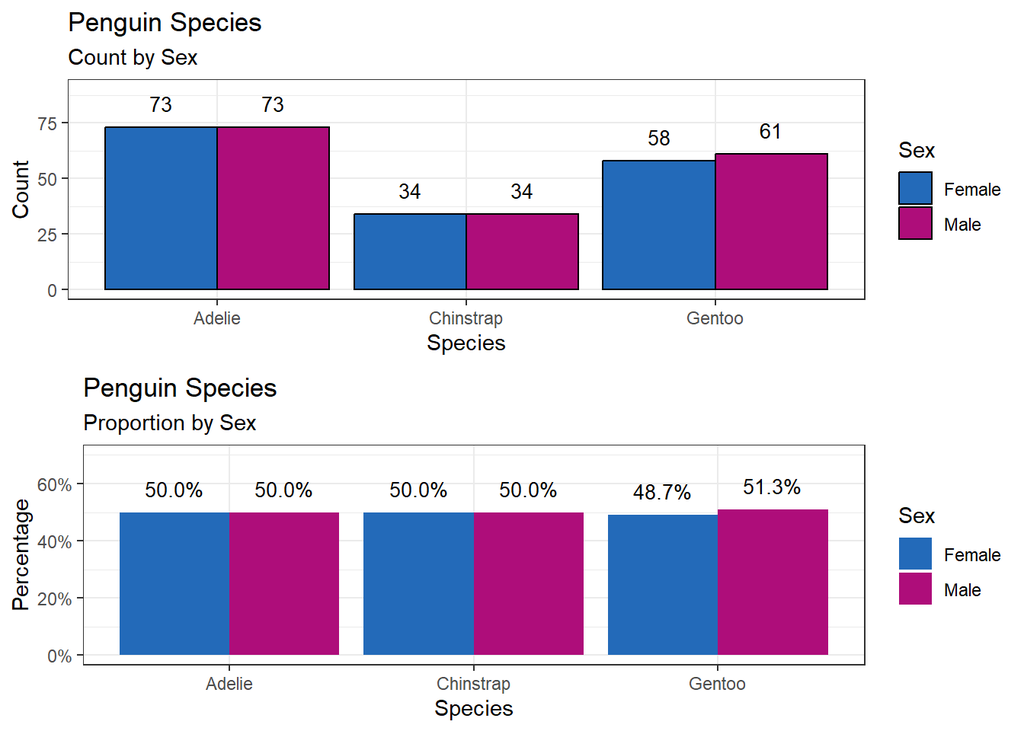

```r
# combine both graphs
grid.arrange(g2, p2, ncol = 1)
```

**4. Suppose we want to predict the sex of the penguin.**

**4a. Construct the regression model that models sex as a function of bill length (*bill_length_mm*), body mass (*body_mass_g*), and flipper length (*flipper_length_mm*). Remember to state the resulting model.**

```r
m1 <- glm(sex ~ bill_length_mm + body_mass_g + flipper_length_mm,
          data = data,
          family = binomial,
          na.action = na.exclude)
summary(m1)
```

```
Call:
glm(formula = sex ~ bill_length_mm + body_mass_g + flipper_length_mm,
    family = binomial, data = data, na.action = na.exclude)

Deviance Residuals:
    Min       1Q   Median       3Q      Max
-2.5691  -0.9023   0.1991   0.8757   2.3051

Coefficients:
                    Estimate Std. Error z value Pr(>|z|)
(Intercept)        8.2569324  2.7636399   2.988  0.00281 **
bill_length_mm     0.1458945  0.0332279   4.391 1.13e-05 ***
body_mass_g        0.0029604  0.0004188   7.069 1.56e-12 ***
flipper_length_mm -0.1348614  0.0234043  -5.762 8.30e-09 ***
---
Signif. codes:  0 '***' 0.001 '**' 0.01 '*' 0.05 '.' 0.1 ' ' 1

(Dispersion parameter for binomial family taken to be 1)

    Null deviance: 461.61  on 332  degrees of freedom
Residual deviance: 350.73  on 329  degrees of freedom
  (11 observations deleted due to missingness)
AIC: 358.73

Number of Fisher Scoring iterations: 4
```

```r
c <- coefficients(m1)
```

$$\ln \left( \frac{\hat{\pi}}{1-\hat{\pi}} \right) = 8.257 + 0.146 \text{ bill length} + 0.003 \text{ body mass} -0.1350 \text{ flipper length}$$

**4b. Use the appropriate hypothesis tests to determine if there are any significant predictors of sex. You do not need to state all parts of the hypothesis tests, but you must justify your answer statistically.**

All predictors are significant:

- Bill Length ($p < 0.001$)
- Body Mass ($p < 0.001$)
- Flipper Length ($p < 0.001$)

**4c. Find the odds ratios for all of the predictors in the model.**

```r
round(exp(coefficients(m1)[-1]), 3)
```

```
   bill_length_mm       body_mass_g flipper_length_mm
            1.157             1.003             0.874
```

```r
# (1-1.157)*-100
# (1-1.003)*-100
# (1-0.874)*-100
```

**4d. Provide interpretations for each of the odds ratios.**

- For 1mm increase in Bill Length, the odds of predicting the penguin sex is multiplied by 1.157, which is a 15.7% increase.
- For 1g increase in Body Mass, the odds of predicting the penguin sex is multiplied by 1.003, which is a 0.3% increase.
- For 1mm increase in Flipper Length, the odds of predicting the penguin sex is multiplied by 0.874, which is a 12.6% decrease.

**4e. Construct the 95% confidence intervals for the odds ratios.**

```r
round(exp(confint(m1)),3)
```

```
                   2.5 %     97.5 %
(Intercept)       19.104 999243.586
bill_length_mm     1.086      1.237
body_mass_g        1.002      1.004
flipper_length_mm  0.833      0.913
```

**4f. Use the Confusion Matrix metrics discussed in the last lecture to determine if this is a good model.**

- The Confusion Matrix has good, and realistic metrics with accuracy of 71.47%.
- The model has high scores for True Positives (TP = 123) and True Negative (TN = 115), while low False Positives (FP = 50) and False Negatives (FN = 45) rates.

Below, further metrics have been documented in greater detail.

```r
# get predicted values
data <- data %>%
  mutate(p_hat = predict(m1, type = "response"))

# misclassification error
data <- data %>%
  mutate(Predict = ifelse(p_hat > 0.5, 1, 0))

# change sex variable levels to 0 & 1
levels(data$sex) <- list("0" = "female", "1" = "male")

# get Confusion Matrix cross-table with 0 & 1 levels
CrossTable(data$Predict, data$sex,
           prop.r = FALSE,
           prop.c = FALSE,
           prop.t = FALSE,
           prop.chisq = FALSE)
```

```
   Cell Contents
|-------------------------|
|                       N |
|-------------------------|


Total Observations in Table:  333


             | data$sex
data$Predict |         0 |         1 | Row Total |
-------------|-----------|-----------|-----------|
           0 |       115 |        45 |       160 |
-------------|-----------|-----------|-----------|
           1 |        50 |       123 |       173 |
-------------|-----------|-----------|-----------|
Column Total |       165 |       168 |       333 |
-------------|-----------|-----------|-----------|
```

```r
# convert to factor
Actual <- factor(data$sex)
Predicted <- factor(data$Predict)

# get confusion matrix function
confusionMatrix(Predicted, Actual, positive = "1")
```

```
Confusion Matrix and Statistics

          Reference
Prediction   0   1
         0 115  45
         1  50 123

               Accuracy : 0.7147
                 95% CI : (0.6629, 0.7626)
    No Information Rate : 0.5045
    P-Value [Acc > NIR] : 4.814e-15

                  Kappa : 0.4292

 Mcnemar's Test P-Value : 0.6815

            Sensitivity : 0.7321
            Specificity : 0.6970
         Pos Pred Value : 0.7110
         Neg Pred Value : 0.7188
             Prevalence : 0.5045
         Detection Rate : 0.3694
   Detection Prevalence : 0.5195
      Balanced Accuracy : 0.7146

       'Positive' Class : 1
```

## Confusion Matrix

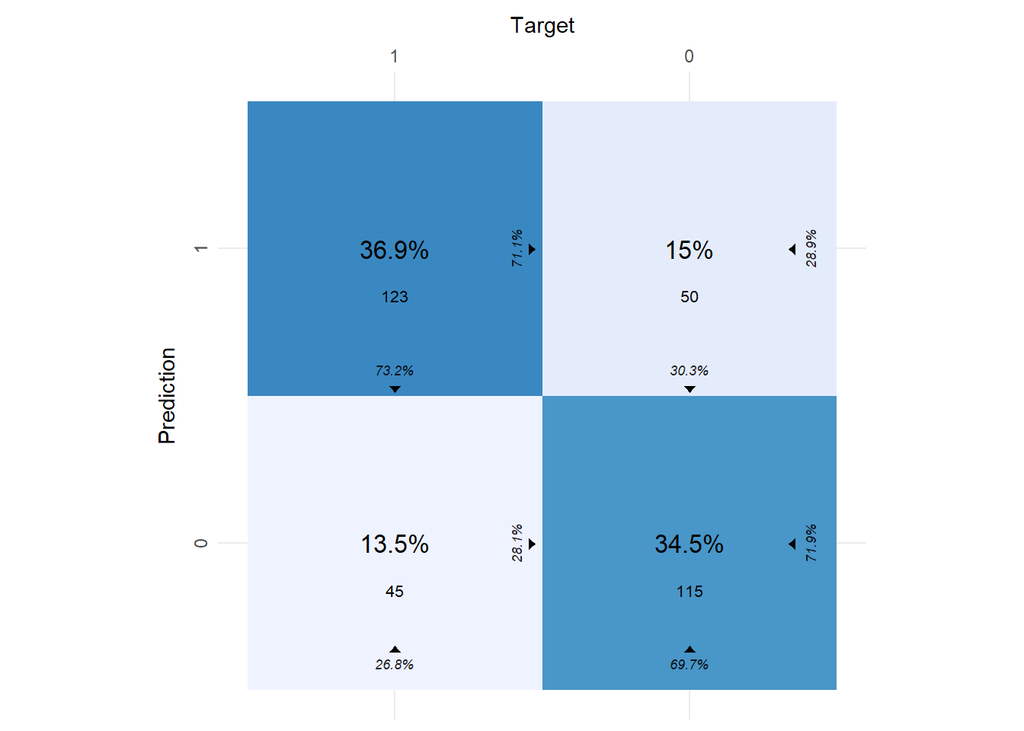

```r
# plot confusion matrix
base_matrix <- tibble("Predicted" = c(0, 0, 1, 1),
                      "Actual" =    c(0, 1, 0, 1),
                      "Counts" =    c(115, 45, 50, 123))

plot_confusion_matrix(base_matrix,
                      target_col = "Actual",
                      prediction_col = "Predicted",
                      counts_col = "Counts")
```

### Sensitivity

```r
tn = 115
fn = 45
fp = 50
tp = 123

# get sensitivity (recall)
sensitivity = tp / (tp + fn)
round(sensitivity, 3)
```

```
[1] 0.732
```

### Specificity

```r
# get specificity
specificity = tn / (tn + fp)
round(specificity, 3)
```

```
[1] 0.697
```

### Positive Predictive Value

```r
# get positive predictive value (Precision)
pos_pred_value = tp / (tp + fp)
round(pos_pred_value, 3)
```

```
[1] 0.711
```

### Negative Predictive Value

```r
# get negative predictive value
neg_pred_value = tn / (tn + fn)
round(neg_pred_value, 3)
```

```
[1] 0.719
```

### Miscalculation Error

```r
# get miscalculation error
# (fp+fn)/(tp+tn+fp+fn)
# 1 - Accuracy
1 - 0.7147
```

```
[1] 0.2853
```